# Week 2: Bonus Material

## 1. Overview

Author: Helene Wagner

### a) Goals

This bonus material expands the Worked Exakmple to show:

- How to use a new standard for spatial data (‘sf’ package).
- How to plot site attributes in space (‘sf’ package)
- How to export the site data to a shapefile for import into a GIS (‘sf’ package).
- How to plot a categorical raster map with a predefined color scheme.

Try modifying the code to import your own data!

### b) Required R libraries

```r
require(sp)
require(sf)
require(raster)
require(GeNetIt)
require(rasterVis)
require(tmaptools)
```

## 2. Convert ‘SpatialPointsDataFrame’ to ‘sf’ object

While ‘sp’ was a major achievement, it is being replaced now by ‘sf’, which is short for “simple feature”. The conversion is easy. The resulting S3 object is a data frame and also an ‘sf’ object.

```r
data(ralu.site)
Sites.sf <- st_as_sf(ralu.site)
class(Sites.sf)
```

```
[1] "sf"         "data.frame"
```

## 3. Plot variables (first 10 in data set)

If we use ‘plot’ on this ‘sf’ object, it will plot site attribute data in space! Here we set the point character ‘pch’ to a filled circle, which is symbol #16.

For an overview of ‘pch’ symbol numbers, and colors, check: http://vis.supstat.com/2013/04/plotting-symbols-and-color-palettes/

```
plotting the first 10 out of 17 attributes; use max.plot = 17 to plot all
```

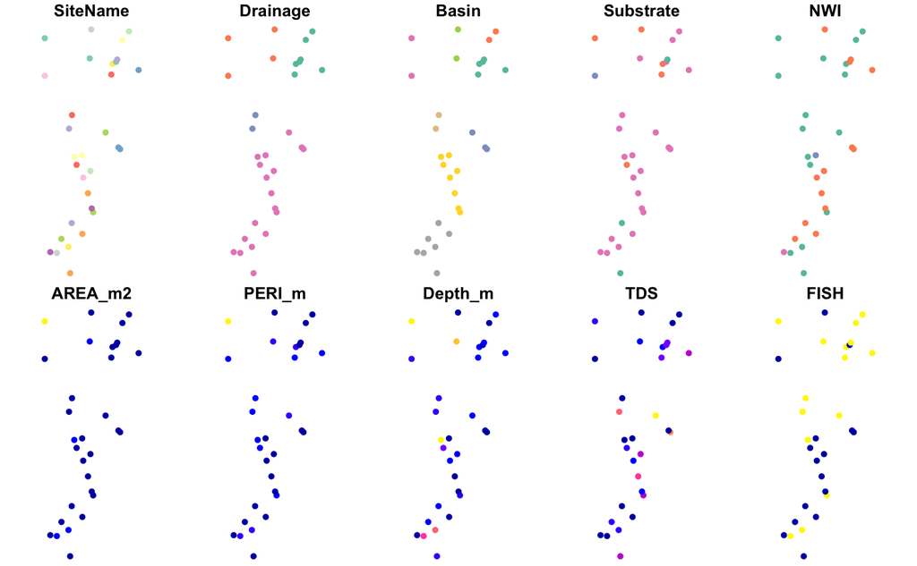

```r
plot(Sites.sf, pch=16)
```

This is pretty cool! Let’s have a closer look at the variables ‘Drainage’ and ‘Basin’. These are factors, and each factor level is assigned a different color:

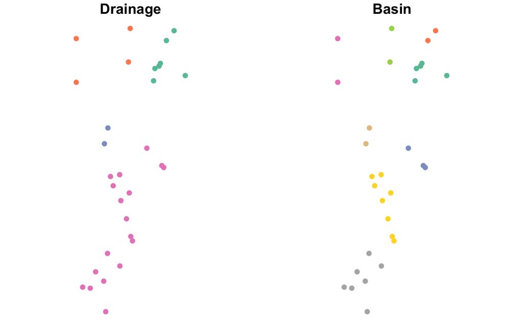

```r
plot(Sites.sf[,c("Drainage", "Basin")], pch=16)
```

Note: To learn about options for the ‘plot’ function for ‘sf’ objects, access the help file by typing ‘?plot’ and select ‘Plot sf object’.

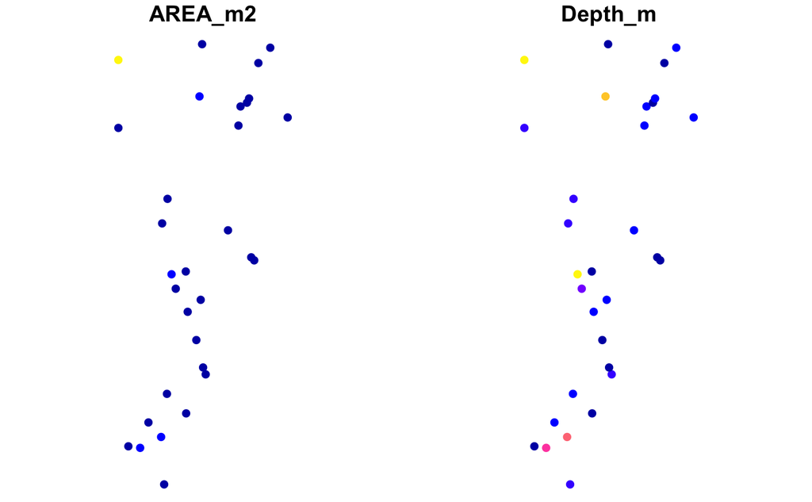

```r
plot(Sites.sf[,c("AREA_m2", "Depth_m")], pch=16)
```

## 4. Export site data as ESRI shapefile

The argument ‘delete_dsn’ specifies whether any existing file with the same name should be deleted first (i.e., overwritten).

```r
st_write(Sites.sf, "Sites.shp", delete_dsn = TRUE)
```

```
Deleting source `/Users/hhwagner1/Desktop/TestCoursePackage/inst/WE/Sites.shp' using driver `ESRI Shapefile'
Writing layer `Sites' to data source `/Users/hhwagner1/Desktop/TestCoursePackage/inst/WE/Sites.shp' using driver `ESRI Shapefile'
features:       31
fields:         17
geometry type:  Point
```

## 5. Display categorical map with a predefined color table

Now to a more tricky topica. Recall that the last raster layer in the Worked Example, ‘nlcd’, contains categorial land cover data that are coded numerically. The ‘raster’ package actually misinterpreted them as numeric data.

Let’s again extract the categorical raster layer into a new object ‘NLCD’.

```r
data(rasters)
NLCD <- raster(rasters[6])
NLCD
```

```
class       : RasterLayer
dimensions  : 426, 358, 152508  (nrow, ncol, ncell)
resolution  : 30, 30  (x, y)
extent      : 683282.5, 694022.5, 4992833, 5005613  (xmin, xmax, ymin, ymax)
coord. ref. : +proj=utm +zone=11 +datum=NAD83 +units=m +no_defs +ellps=GRS80 +towgs84=0,0,0
data source : in memory
names       : nlcd
values      : 11, 95  (min, max)
```

Then we use function ‘ratify’ to tell R that this is a categorical map (factor) that needs a ‘raster attribute table’ (rat). Nothing to do with rats…

Then create the raster attribute table from the factor levels. This is simply a vector with all factor levels present in ‘NLCD’. The levels are codes as numbers between 11 and 95. Here’s the legend information: https://www.mrlc.gov/nlcd06_leg.php

```r
NLCD <- ratify(NLCD)
rat <- levels(NLCD)[[1]]
rat
```

| ID |
| --- |
| 11 |
| 12 |
| 31 |
| 42 |
| 52 |
| 71 |
| 90 |
| 95 |

Let’s add some columns with labels and predefined colors (using hex color code). A color table (“Colortable_LULC.csv”) is already in the data folder.

It has more rows than we need, because not all US land cover classes occur in the study area. We need to make sure the colors and cover types are stored as ‘character’, because the missing factor levels would later create problems.

```r
ColTab <- read.csv(system.file("extdata", "Colortable_LULC.csv",
                            package = "TestCoursePackage"), header=TRUE)
ColTab$color <- as.character(ColTab$color)
ColTab$attribute <- as.character(ColTab$attribute)
ColTab
```

| value | color | attribute |
| --- | --- | --- |
| 11 | #456DA8 | Open Water |
| 12 | #E6EEF9 | Perennial Ice/Snow |
| 21 | #E1CBCD | Developed, Open Space |
| 22 | #DC9786 | Developed, Low Intensity |
| 23 | #F40100 | Developed, Medium Intensity |
| 24 | #B00206 | Developed, High Intensity |
| 31 | #B2AEA3 | Barren Land (Rock/Sand/Clay) |
| 41 | #6BA95C | Deciduous Forest |
| 42 | #16692E | Evergreen Forest |
| 43 | #B9CA8F | Mixed Forest |

[output cut: 10 more lines]

Now we need to match the codes in ‘NLCD.rat’ and ‘ColTab’ and extract the additional variables for the land use categories that occur in NLCD. We can use the function ‘merge’ to do this.

Finally we tell R that the factor levels of NLCD are defined in ‘rat’, and R stores the information in the slot ‘NLCD@data@attributes’.

```r
rat <- merge(rat, ColTab, by.x="ID", by.y="value", all=FALSE, sort=TRUE)
levels(NLCD) <- rat
NLCD@data@attributes
```

| ID | color | attribute |
| --- | --- | --- |
| 11 | #456DA8 | Open Water |
| 12 | #E6EEF9 | Perennial Ice/Snow |
| 31 | #B2AEA3 | Barren Land (Rock/Sand/Clay) |
| 42 | #16692E | Evergreen Forest |
| 52 | #D5B883 | Shrub/Scrub |
| 71 | #EDEFCA | Grassland/Herbaceous |
| 90 | #BED8F6 | Woody Wetlands |
| 95 | #6EA5C4 | Emergent Herbaceous Wetlands |

```
NA
```

Now we can use the function ‘levelplot’ (package ‘rasterVis’) to plot the land cover map with the correct color scheme and legend. We will overlay the sampling locations, using yellow circles with black outlines.

This code uses advanced plotting ‘language’, where we first define ‘Map’ as the levelplot of the categorical map. The argument ‘att’ specifies which column in the ‘rat’ should be used for the labels, ‘colorkey’ scales the size of the legend, and ‘col.regions’ defines the color scheme.

Unfortunately the colorscheme is not taken directly from NLCD@data@attributes, and we have to order colors according to the alphabetical order of the labels. This is done here by defining ‘myOrder’ and using it to sort ‘col.regions’.

Now we can plot ‘Map’ simply by writing its name, and we can add layers to it with ‘+ layers’.

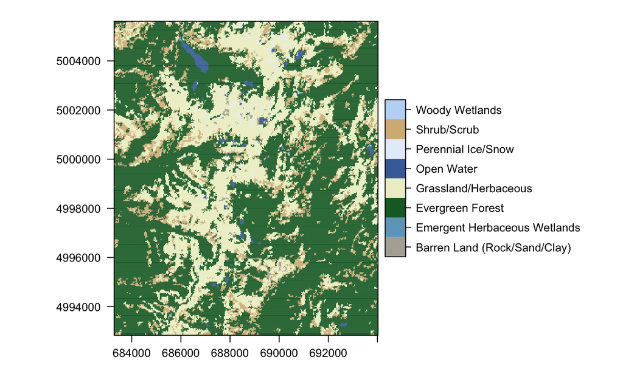

```r
myOrder <- order(NLCD@data@attributes[[1]]$attribute)
Map <- levelplot(NLCD, att='attribute', colorkey=list(height=0.5),
          col.regions=NLCD@data@attributes[[1]]$color[myOrder])
Map
```

Additional layers are added to the map with ‘+ layer()’: first we add a layer with the yellow filled circles at the sampling locations, then another layer with the black symbol outlines.

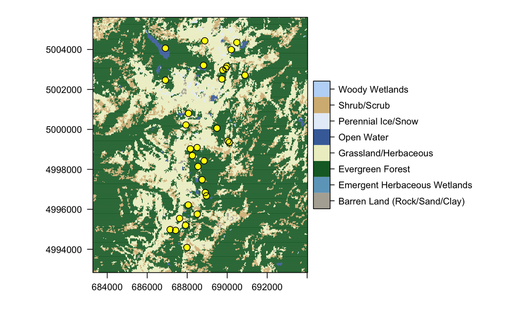

```r
Map + layer(sp.points(Sites.sp, pch=16, col="yellow", cex=1.1)) +
  layer(sp.points(Sites.sp, pch=1, col="black", cex=1.1))
```